# Titans Trade Derrick Henry

Matthew Flaherty

January 06, 2021

# 1 Introduction

The 2020 season for the Tennessee Titans has been one to remember. They won their first AFC South division title since 2008 while also having a potent offense. This sounds amazing; however, the defense has been lack luster and could pose a problem on their route to Superbowl LV. Although the season is not quite yet over, we can still look forward to next season while enjoying this memorable one. Things will get more difficult as the Titans will play a first place schedule in 2021 while rumors of offensive coordinator, Arthur Smith, for other head coaching positions loom. This will be an important offseason for the team as a false step could hinder the team’s potential moving forward.

In this post, I want to take a look at the expected points added (EPA) of both Ryan Tannehill and Derrick Henry of the Tennessee Titans. Derrick Henry has just concluded a 2,000 rushing yard regular season in which his first half numbers would have been the fourth most rushing yards for the year. Is this the way forward? Certainly it could win yet another AFC South division championship as it did in 2020 and certainly it could get them back into the AFC conference championship game as it did in 2019. But what if there was a way to get over this hump and reach/win the superbowl. This post will delve into Tannehill and Henry’s offensive production to determine if either player is as valuable as they seem.

# 2 Background

# 3 Data

The data for this post will come from the 2020 NFL season. I only want the Titans offensive plays. Thus, I will filter the main data frame when `posteam` has the value `TEN`. I also only want pass and run plays so I filter by `pass` equals to 1 (TRUE) and `rush` equals to 1 (TRUE).

```r
seasons <- 2020
pbp <- purrr::map_df(seasons, function(x) {
  readRDS(
    url(
      glue::glue("https://raw.githubusercontent.com/guga31bb/nflfastR-data/master/data/play_by_play_{x}.rds")
    )
  )
})
```

# 4 Methods

Having retrieved the Titans offensive data, I can take a look into the average EPA per play for Tannehill and Henry. I will do a sample of 10,000 bootstrap observations to determine the 95% confidence interval (CI) for Tannehill and Henry.

## 4.1 Tannehill Stats

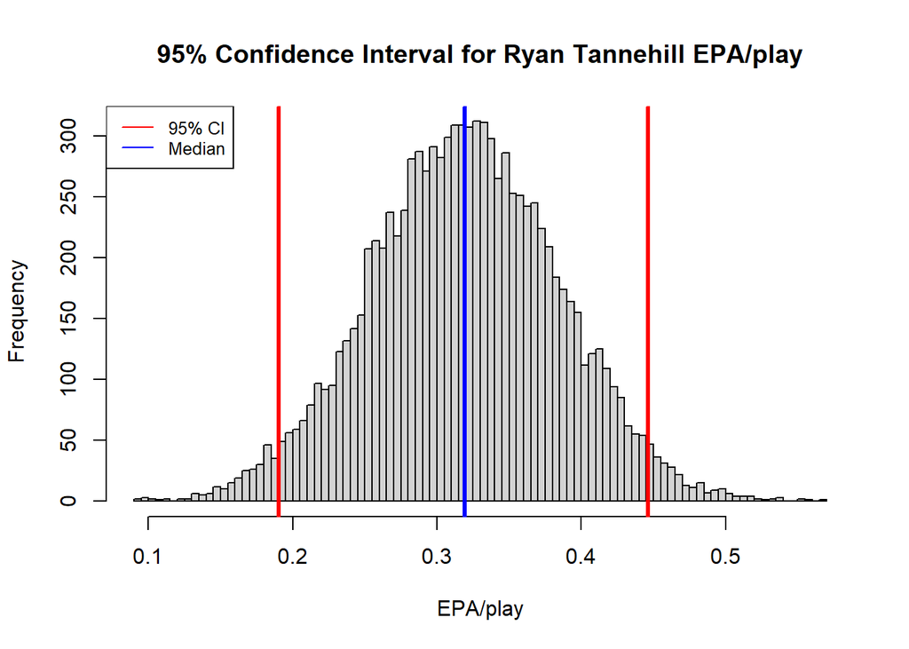

```r
hist(tan_out, main = "95% Confidence Interval for Ryan Tannehill EPA/play", xlab = "EPA/play", breaks = 100)
abline(v = tan_ci[1], col = "red", lwd = 3)
abline(v = tan_ci[2], col = "red", lwd = 3)
abline(v = median(tan_out), col = "blue", lwd = 3)
legend("topleft", legend=c("95% CI", "Median"),
       col=c("red", "blue"), lty = 1, cex = 0.8)
```

## 4.2 Henry Stats

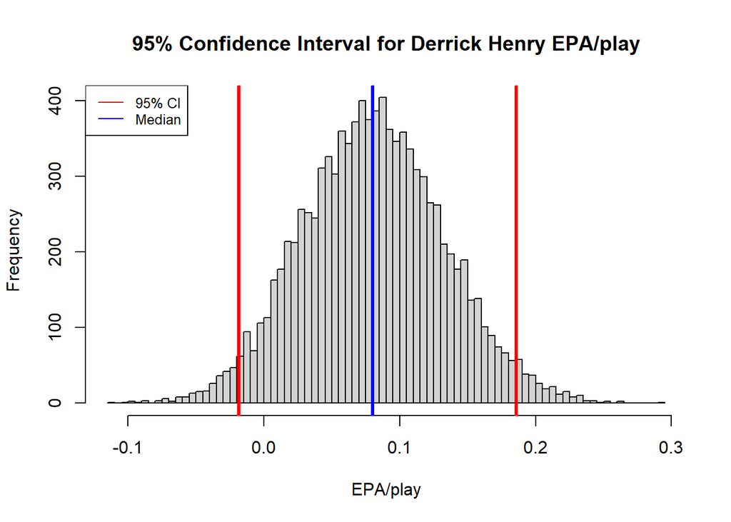

```r
hist(hen_out, main = "95% Confidence Interval for Derrick Henry EPA/play", xlab = "EPA/play", breaks = 100)
abline(v = hen_ci[1], col = "red", lwd = 3)
abline(v = hen_ci[2], col = "red", lwd = 3)
abline(v = median(hen_out), col = "blue", lwd = 3)
legend("topleft", legend=c("95% CI", "Median"),
       col=c("red", "blue"), lty = 1, cex = 0.8)
```

# 5 Results

The results show that the average EPA/play for Tannehill (0.1901477, 0.446422) is significantly better than Henry (-0.0184657, 0.185689) at the 95% CI.